# Customer Shopping Association Rules for Tenant Synergy Analysis

Nabiilah Ardini Fauziyyah

9/2/2019

## Import Library

```r
library(dplyr) # for data wrangling
library(tidyr) # for data wrangling
library(stringr) # for data wrangling
library(arules) # for association rules analysis
library(visNetwork) # for Vizualization Network
```

## Read Data

The dummy data contains Date, Costumer ID (code), and various mall tenants which were visited on each day by each costumer.

```r
# wide data format
mall <- read.csv("data_input/dummy_arules.csv")
head(mall)
```

|  | Date | CostumerID | Celebrity.Fitness | CGV | Chatime | Daiso | Erha.Dermatologist | Fossil | Gramedia | Guardian | H.M | KOI | Kopi.Kenangan | Miniso | Pandora | Pull.Bear | Sport.Station | The.Body.Shop | The.Executive | Uniqlo | Yoshinoya | ZARA |
| --- | --- | --- | --- | --- | --- | --- | --- | --- | --- | --- | --- | --- | --- | --- | --- | --- | --- | --- | --- | --- | --- | --- |
| 1 | 1/1/2019 | A | 1 | 1 | 1 | 0 | 0 | 0 | 1 | 1 | 1 | 0 | 1 | 1 | 1 | 1 | 1 | 1 | 0 | 0 | 0 | 1 |
| 2 | 1/1/2019 | B | 1 | 1 | 1 | 0 | 0 | 0 | 0 | 1 | 1 | 1 | 0 | 0 | 0 | 0 | 0 | 0 | 1 | 1 | 1 | 1 |
| 3 | 1/1/2019 | C | 1 | 1 | 0 | 1 | 0 | 1 | 0 | 0 | 0 | 0 | 1 | 1 | 1 | 0 | 1 | 0 | 1 | 1 | 1 | 0 |
| 4 | 1/1/2019 | D | 0 | 1 | 1 | 0 | 1 | 0 | 1 | 0 | 0 | 1 | 0 | 1 | 0 | 0 | 1 | 1 | 0 | 0 | 1 | 0 |
| 5 | 1/1/2019 | E | 0 | 1 | 0 | 1 | 1 | 1 | 0 | 1 | 1 | 0 | 0 | 1 | 1 | 1 | 1 | 1 | 0 | 0 | 0 | 0 |
| 6 | 1/2/2019 | A | 1 | 1 | 1 | 0 | 0 | 1 | 1 | 0 | 0 | 1 | 1 | 1 | 1 | 1 | 0 | 1 | 1 | 1 | 1 | 1 |

In the practice, you might need to transform your data from and into a **wide/long data format**. Below are examples of each data format and how to transform between each one using `spread()` and `gather()` from tidyr package.

```r
# long data format
transactional <- mall %>%
  gather(Tenant, Value, 3:22) %>%
  filter(Value == 1) %>%
  select(-Value) %>%
  filter(CostumerID  != '') %>%
  arrange(Date, CostumerID)

head(transactional, 20)
```

|  | Date | CostumerID | Tenant |
| --- | --- | --- | --- |
| 1 | 1/1/2019 | A | Celebrity.Fitness |
| 2 | 1/1/2019 | A | CGV |
| 3 | 1/1/2019 | A | Chatime |
| 4 | 1/1/2019 | A | Gramedia |
| 5 | 1/1/2019 | A | Guardian |
| 6 | 1/1/2019 | A | H.M |
| 7 | 1/1/2019 | A | Kopi.Kenangan |
| 8 | 1/1/2019 | A | Miniso |
| 9 | 1/1/2019 | A | Pandora |
| 10 | 1/1/2019 | A | Pull.Bear |

[output cut: 10 more lines]

```r
price_range <- data.frame(tenant=unique(transactional$Tenant), mean = c(0, 50000, 25000, 120000, 27000, 500000, 18000, 50000, 200000, 300000, 500000, 300000, 800000, 35000, 300000, 700000, 50000, 50000, 1000000, 750000), sd = c(750000, 5000, 5000, 80000, 15000, 150000, 5000, 30000, 100000, 300000, 300000, 200000, 300000, 10000, 150000, 500000, 30000, 30000, 300000, 200000))

price_est <- function(x){
  attr <- price_range %>%
    filter(tenant == x)

  return(rnorm(1, attr$mean, attr$sd))
}

price_est('Uniqlo')
```

```
## [1] 1255958
```

```r
transactional <- transactional %>%
  mutate(
    DiscountVoucher = 0,
    SalesSubTotal = round(abs(purrr::map(Tenant, price_est) %>% unlist))
  )

# write.csv(transactional, "data_input/transactions.csv", row.names = FALSE)
transactional
```

| Date | CostumerID | Tenant | DiscountVoucher | SalesSubTotal |
| --- | --- | --- | --- | --- |
| 1/1/2019 | A | Celebrity.Fitness | 0 | 12746 |
| 1/1/2019 | A | CGV | 0 | 38624 |
| 1/1/2019 | A | Chatime | 0 | 26983 |
| 1/1/2019 | A | Gramedia | 0 | 291676 |
| 1/1/2019 | A | Guardian | 0 | 28937 |
| 1/1/2019 | A | H.M | 0 | 540241 |
| 1/1/2019 | A | Kopi.Kenangan | 0 | 15139 |
| 1/1/2019 | A | Miniso | 0 | 46122 |
| 1/1/2019 | A | Pandora | 0 | 373625 |
| 1/1/2019 | A | Pull.Bear | 0 | 1102282 |

[output cut: 257 more lines]

```r
# example of making a wide into a long data format using `gather()`
dat <- tibble::tibble(
  Precinct = c(1, 1, 1, 2),
  Crime = c("Murder", "Rape", "Burglary", "Murder"),
  `2000` = c(3, 12, 252, 4),
  `2001` = c(1, 5, 188, 2),
  `2002` = c(2, 10, 297, 1),
  `2003` = c(2, 11, 403, 0)
)

dat
```

| Precinct | Crime | 2000 | 2001 | 2002 | 2003 |
| --- | --- | --- | --- | --- | --- |
| 1 | Murder | 3 | 1 | 2 | 2 |
| 1 | Rape | 12 | 5 | 10 | 11 |
| 1 | Burglary | 252 | 188 | 297 | 403 |
| 2 | Murder | 4 | 2 | 1 | 0 |

```r
# tidyr::gather(dat, Year, Value, 3:6) <--- another way
tidyr::gather(dat, Year, Value, -Precinct, -Crime)
```

| Precinct | Crime | Year | Value |
| --- | --- | --- | --- |
| 1 | Murder | 2000 | 3 |
| 1 | Rape | 2000 | 12 |
| 1 | Burglary | 2000 | 252 |
| 2 | Murder | 2000 | 4 |
| 1 | Murder | 2001 | 1 |
| 1 | Rape | 2001 | 5 |
| 1 | Burglary | 2001 | 188 |
| 2 | Murder | 2001 | 2 |
| 1 | Murder | 2002 | 2 |
| 1 | Rape | 2002 | 10 |

[output cut: 6 more lines]

### Transactional to Matrix

We will probably see more of the long data format and we need to transform it into a wide format. The wide format is a *matrix* compromising a status of visit (1) for each mall tenants on each day by each costumer. Below are the steps to transform our `transactional` data into a matrix.

```r
transactional %>%
  select(Date, CostumerID, Tenant) %>%
  mutate(
    Indicator = 1
  ) %>%
  spread(Tenant, Indicator, fill=0) # `spread()` is the opposite of `gather()`
```

| Date | CostumerID | Celebrity.Fitness | CGV | Chatime | Daiso | Erha.Dermatologist | Fossil | Gramedia | Guardian | H.M | KOI | Kopi.Kenangan | Miniso | Pandora | Pull.Bear | Sport.Station | The.Body.Shop | The.Executive | Uniqlo | Yoshinoya | ZARA |
| --- | --- | --- | --- | --- | --- | --- | --- | --- | --- | --- | --- | --- | --- | --- | --- | --- | --- | --- | --- | --- | --- |
| 1/1/2019 | A | 1 | 1 | 1 | 0 | 0 | 0 | 1 | 1 | 1 | 0 | 1 | 1 | 1 | 1 | 1 | 1 | 0 | 0 | 0 | 1 |
| 1/1/2019 | B | 1 | 1 | 1 | 0 | 0 | 0 | 0 | 1 | 1 | 1 | 0 | 0 | 0 | 0 | 0 | 0 | 1 | 1 | 1 | 1 |
| 1/1/2019 | C | 1 | 1 | 0 | 1 | 0 | 1 | 0 | 0 | 0 | 0 | 1 | 1 | 1 | 0 | 1 | 0 | 1 | 1 | 1 | 0 |
| 1/1/2019 | D | 0 | 1 | 1 | 0 | 1 | 0 | 1 | 0 | 0 | 1 | 0 | 1 | 0 | 0 | 1 | 1 | 0 | 0 | 1 | 0 |
| 1/1/2019 | E | 0 | 1 | 0 | 1 | 1 | 1 | 0 | 1 | 1 | 0 | 0 | 1 | 1 | 1 | 1 | 1 | 0 | 0 | 0 | 0 |
| 1/2/2019 | A | 1 | 1 | 1 | 0 | 0 | 1 | 1 | 0 | 0 | 1 | 1 | 1 | 1 | 1 | 0 | 1 | 1 | 1 | 1 | 1 |
| 1/2/2019 | B | 1 | 1 | 0 | 0 | 0 | 1 | 0 | 0 | 1 | 1 | 1 | 0 | 1 | 1 | 1 | 1 | 1 | 0 | 0 | 0 |
| 1/2/2019 | C | 0 | 1 | 1 | 1 | 0 | 1 | 1 | 0 | 0 | 0 | 1 | 0 | 0 | 1 | 0 | 1 | 1 | 1 | 1 | 1 |
| 1/2/2019 | D | 0 | 0 | 1 | 1 | 1 | 1 | 0 | 1 | 0 | 0 | 0 | 0 | 1 | 0 | 1 | 0 | 1 | 1 | 1 | 1 |
| 1/2/2019 | E | 0 | 1 | 1 | 0 | 1 | 0 | 1 | 1 | 0 | 1 | 0 | 0 | 1 | 1 | 1 | 1 | 1 | 1 | 0 | 1 |

[output cut: 15 more lines]

## Pre-process Data

**Apriori algorithm** for **Association Rules** analysis in R can only process data in (or can be transformed into) transaction format. To make one, we can change the structure of our data into a *basket format* and then a *transaction format*.

```r
# making a basket format - 3 days, 6 Tenants
mgat <- mall[,c(1:8)] %>%
  filter(Date==c("1/1/2019", "1/2/2019", "1/3/2019")) %>% # filter for each day visit
  gather(key, value, -CostumerID, -Date) %>%
  filter(value == 1) %>% # indicates visit
  select(-value) %>% # clean off
  mutate(Tenant=as.factor(key)) %>% # making factor for basket format
  select(-key) # clean off

class(mgat)
```

```
## [1] "data.frame"
```

```r
mgat
```

| Date | CostumerID | Tenant |
| --- | --- | --- |
| 1/1/2019 | A | Celebrity.Fitness |
| 1/3/2019 | B | Celebrity.Fitness |
| 1/3/2019 | E | Celebrity.Fitness |
| 1/1/2019 | A | CGV |
| 1/1/2019 | D | CGV |
| 1/2/2019 | C | CGV |
| 1/3/2019 | E | CGV |
| 1/1/2019 | A | Chatime |
| 1/1/2019 | D | Chatime |
| 1/2/2019 | C | Chatime |

[output cut: 9 more lines]

```r
# changing data.frame into a list (basket) format
basket <- split(x = mgat$Tenant, # column to be splitted into groups
                f = list(mgat$CostumerID,mgat$Date), # splitted column to be grouped by other column
                drop = T) # drop groups which have no item (Tenant)

class(basket)
```

```
## [1] "list"
```

```r
basket
```

```
## $`A.1/1/2019`
## [1] Celebrity.Fitness CGV               Chatime
## Levels: Celebrity.Fitness CGV Chatime Daiso Erha.Dermatologist Fossil
##
## $`D.1/1/2019`
## [1] CGV                Chatime            Erha.Dermatologist
## Levels: Celebrity.Fitness CGV Chatime Daiso Erha.Dermatologist Fossil
##
## $`C.1/2/2019`
## [1] CGV     Chatime Daiso   Fossil
## Levels: Celebrity.Fitness CGV Chatime Daiso Erha.Dermatologist Fossil
##
## $`B.1/3/2019`
## [1] Celebrity.Fitness  Chatime            Erha.Dermatologist Fossil
## Levels: Celebrity.Fitness CGV Chatime Daiso Erha.Dermatologist Fossil
##
## $`E.1/3/2019`
## [1] Celebrity.Fitness  CGV                Chatime            Daiso
## [5] Erha.Dermatologist
## Levels: Celebrity.Fitness CGV Chatime Daiso Erha.Dermatologist Fossil
```

```r
# changing list into transaction format
trans <- as(basket, "transactions")
trans
```

```
## transactions in sparse format with
##  5 transactions (rows) and
##  6 items (columns)
```

## Arules

For mall management analysis, we would like to see the importance of each tenant on the mall’s popularity/significance, which can be seen through how much costumers visit each tenant on a daily basis. We would also like to see the relationship between each tenant to the other tenants in terms of visitor amount. This might give us valuable informations on decision making when a Mall wants to drop a contract with a spesific tenant, etc.

These informations can be derived from the **Support** of a tenant and the **Lift** between spesific tenants obtained from the apriori algorithms:

**Support**: The support of an item X, `supp(X)` is the proportion of transaction in the database in which the item X appears. **It signifies the popularity of an item.**

**Lift**: This signifies **the likelihood of the item Y being purchased when item X is purchased** while taking into account the popularity (support) of item X and item Y.

*In mall management analysis, the item is the tenant.*

### Support of Tenants

```r
# finding Support of Tenants
tenant.support <- data.frame(Tenant = names(itemFrequency(trans)),
                             Support = itemFrequency(trans))
rownames(tenant.support) <- NULL
tenant.support
```

| Tenant | Support |
| --- | --- |
| Celebrity.Fitness | 0.6 |
| CGV | 0.8 |
| Chatime | 1.0 |
| Daiso | 0.4 |
| Erha.Dermatologist | 0.6 |
| Fossil | 0.4 |

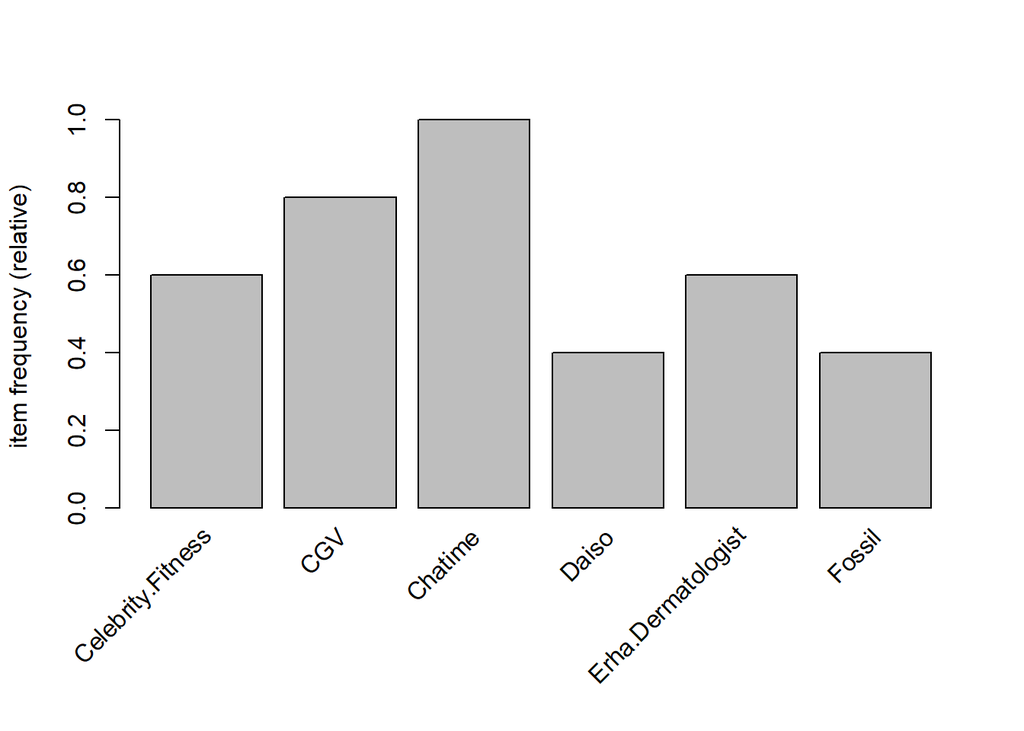

```r
itemFrequencyPlot(trans)
```

### Lift of Tenants

```r
# making association rules
mall_arules <- apriori(data = trans,
                       parameter = list(confidence = 0.5), #filter rules which has confidence >= 0.5
                       control = list(verbose = F))
mall_arules
```

```
## set of 103 rules
```

```r
# to retrieve the first 10 rules
inspect(mall_arules[1:10,])
```

```
##      lhs         rhs                  support confidence lift      count
## [1]  {}       => {Erha.Dermatologist} 0.6     0.6        1.0000000 3
## [2]  {}       => {Celebrity.Fitness}  0.6     0.6        1.0000000 3
## [3]  {}       => {CGV}                0.8     0.8        1.0000000 4
## [4]  {}       => {Chatime}            1.0     1.0        1.0000000 5
## [5]  {Fossil} => {Daiso}              0.2     0.5        1.2500000 1
## [6]  {Daiso}  => {Fossil}             0.2     0.5        1.2500000 1
## [7]  {Fossil} => {Erha.Dermatologist} 0.2     0.5        0.8333333 1
## [8]  {Fossil} => {Celebrity.Fitness}  0.2     0.5        0.8333333 1
## [9]  {Fossil} => {CGV}                0.2     0.5        0.6250000 1
## [10] {Fossil} => {Chatime}            0.4     1.0        1.0000000 2
```

```r
# to retrieve the lift of other tenants (X) to a Y tenant
# eg: what tenants affect the visitor amount of CGV?

CGV_rules <- apriori(data = trans,
                     parameter = list(conf=0.5,
                                      maxlen = 2),
                                      #maxlen specify how many items can be present in one rule
                     appearance = list(default="lhs", rhs ="CGV"))
```

[output not shown]

[output not shown]

```r
inspect(CGV_rules)
```

```
##     lhs                     rhs   support confidence lift      count
## [1] {}                   => {CGV} 0.8     0.8000000  1.0000000 4
## [2] {Fossil}             => {CGV} 0.2     0.5000000  0.6250000 1
## [3] {Daiso}              => {CGV} 0.4     1.0000000  1.2500000 2
## [4] {Celebrity.Fitness}  => {CGV} 0.4     0.6666667  0.8333333 2
## [5] {Erha.Dermatologist} => {CGV} 0.4     0.6666667  0.8333333 2
## [6] {Chatime}            => {CGV} 0.8     0.8000000  1.0000000 4
```

```r
lift <- data.frame(inspect(CGV_rules))
```

```
##     lhs                     rhs   support confidence lift      count
## [1] {}                   => {CGV} 0.8     0.8000000  1.0000000 4
## [2] {Fossil}             => {CGV} 0.2     0.5000000  0.6250000 1
## [3] {Daiso}              => {CGV} 0.4     1.0000000  1.2500000 2
## [4] {Celebrity.Fitness}  => {CGV} 0.4     0.6666667  0.8333333 2
## [5] {Erha.Dermatologist} => {CGV} 0.4     0.6666667  0.8333333 2
## [6] {Chatime}            => {CGV} 0.8     0.8000000  1.0000000 4
```

```r
lift %>%
  select(lhs, rhs, lift)
```

|  | lhs | rhs | lift |
| --- | --- | --- | --- |
| [1] | {} | {CGV} | 1.0000000 |
| [2] | {Fossil} | {CGV} | 0.6250000 |
| [3] | {Daiso} | {CGV} | 1.2500000 |
| [4] | {Celebrity.Fitness} | {CGV} | 0.8333333 |
| [5] | {Erha.Dermatologist} | {CGV} | 0.8333333 |
| [6] | {Chatime} | {CGV} | 1.0000000 |

```r
# finding all X to Y rules
all_rules <- apriori(data = trans,
                     parameter = list(conf=0.8, maxlen = 2),
                     control = list(verbose = F))

all_lift <- DATAFRAME(all_rules)
all_lift <- all_lift %>%
  filter(LHS != "{}") %>%
  select(LHS, RHS, lift)
all_lift
```

| LHS | RHS | lift |
| --- | --- | --- |
| {Fossil} | {Chatime} | 1.00 |
| {Daiso} | {CGV} | 1.25 |
| {Daiso} | {Chatime} | 1.00 |
| {Erha.Dermatologist} | {Chatime} | 1.00 |
| {Celebrity.Fitness} | {Chatime} | 1.00 |
| {CGV} | {Chatime} | 1.00 |
| {Chatime} | {CGV} | 1.00 |

```r
# Remove duplicated rules (X -> Y = Y -> X)?

# clean data
fix_lift <- all_lift %>%
  mutate(LHS = as.character(LHS),
         RHS = as.character(RHS)) %>%
  mutate(LHS = str_replace_all(LHS, "\\{|\\}", ""),
         RHS = str_replace_all(RHS, "\\{|\\}", ""))

names(fix_lift) <- c("Tenant1", "Tenant2", "Lift")

fix_lift
```

| Tenant1 | Tenant2 | Lift |
| --- | --- | --- |
| Fossil | Chatime | 1.00 |
| Daiso | CGV | 1.25 |
| Daiso | Chatime | 1.00 |
| Erha.Dermatologist | Chatime | 1.00 |
| Celebrity.Fitness | Chatime | 1.00 |
| CGV | Chatime | 1.00 |
| Chatime | CGV | 1.00 |

After we have the support and lift of each tenant, we can use the data to be plotted in a Visualization Network.

## Map to VizNetwork

```r
# data preparation
tenant.support <- tenant.support %>%
  # mutate(id = row(tenant.support)[,1])
  rename(id = Tenant, value = Support)
tenant.support
```

| id | value |
| --- | --- |
| Celebrity.Fitness | 0.6 |
| CGV | 0.8 |
| Chatime | 1.0 |
| Daiso | 0.4 |
| Erha.Dermatologist | 0.6 |
| Fossil | 0.4 |

```r
fix_lift <- fix_lift %>%
  rename(from = Tenant1, to = Tenant2,
         weight = Lift)

fix_lift
```

| from | to | weight |
| --- | --- | --- |
| Fossil | Chatime | 1.00 |
| Daiso | CGV | 1.25 |
| Daiso | Chatime | 1.00 |
| Erha.Dermatologist | Chatime | 1.00 |
| Celebrity.Fitness | Chatime | 1.00 |
| CGV | Chatime | 1.00 |
| Chatime | CGV | 1.00 |

```r
set.seed(100)
visNetwork(nodes = tenant.support,
           edges = fix_lift,
           width = "100%") %>%
  visLegend() %>%
  visOptions(nodesIdSelection = T,
             highlightNearest = T)
```

[interactive chart not shown]